# About me

1. Personal Background  
   Sze-Yuan (Lexie) Wang is born in *Taipei* on **February 2, 1999** and she moved to *Shanghai* when she was five years old. She then stayed in Shanghai with her parents until she graduated from college in 2021.
2. Education  
   Sze-Yuan completed her undergraduate degree in July 2021 at **Shanghai University of Finance and Economics**, majoring in Finance. She also completed an exchange study for one semester in University of Pennsylvania in her junior year. She then pursued her masters degree at **London Business School**. She is expected to graduate from LBS’s Masters in Financial Analysis programmed in September 2022.
3. Business Experience  
   Sze-Yuan has developed a genuine interest in investment banking from her previous internship experiences. She has participated in a wide range of deals including an HK IPO, US IPO, A-share IPO, SPAC IPO, M&A and take-private transaction. Through these deal experiences, she has acquried strong financial modeling skills, communication skills, research skills and etc.You can find Sze-Yuan’s linkedin profile at https://www.linkedin.com/in/sze-yuan-lexie-wang-189a241a8.
4. Interests  
   Sze-Yuan’s interests includes traveling, broad games, especially Avalon, and volunteering. She has traveled to more than 10 countries. Her most memorable traveling experience is her trip to Paris where she was accommodated by a French homestay.
5. Photo  
   This is a photo of Sze-Yuan Wang taken in Yellowstone National Park.

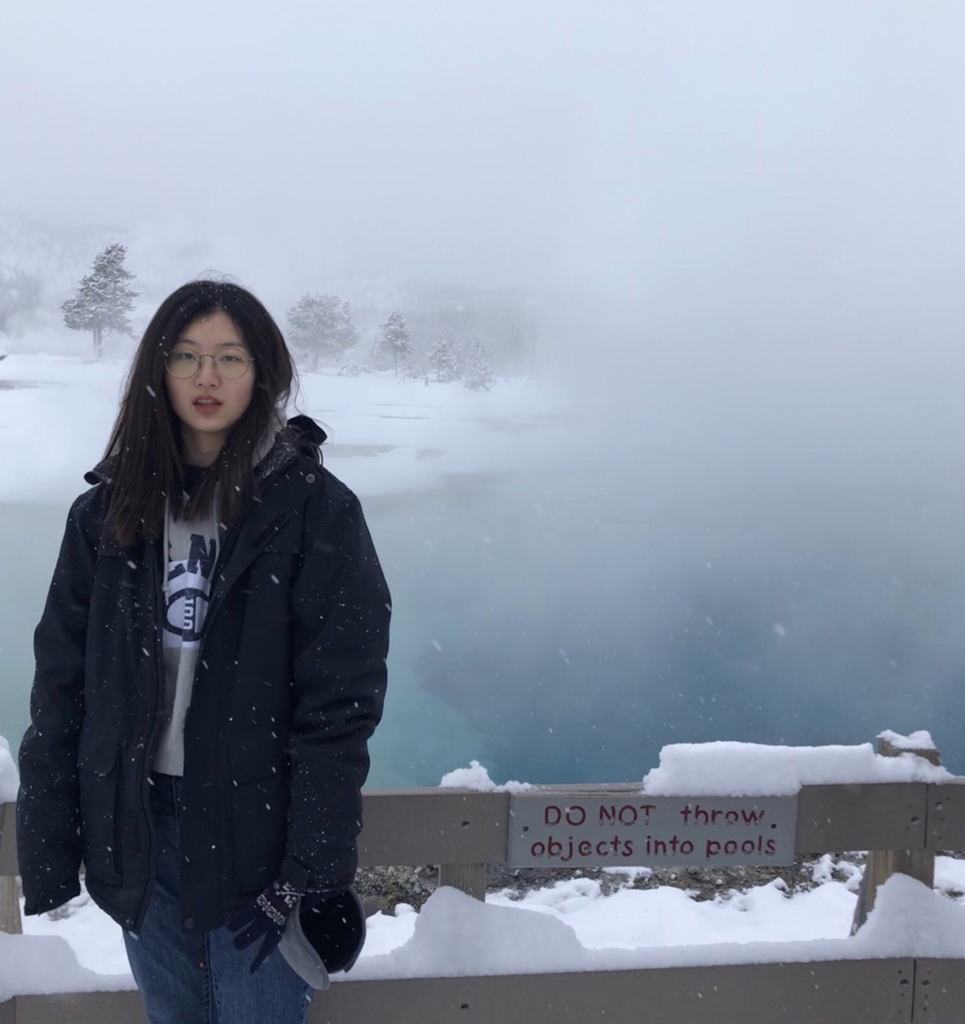